# R Notebook

```r
library(modelr)
```

```r
savings <- CodeClanData::savings

savings
```

| gender | name | surname | job_area | salary | age | retired | location | savings |
| --- | --- | --- | --- | --- | --- | --- | --- | --- |
| Female | Helena | Mowat | Human Resources | 28000 | 48 | No | Western Isles | 31700 |
| Female | Dora | Williamson | Training | 20000 | 55 | No | Edinburgh | 48553 |
| Male | Harry | Halcrow | Product Management | 17000 | 42 | No | Western Isles | 33809 |
| Male | Freddy | Peterson | Legal | 17000 | 66 | Yes | Inverness | 24617 |
| Female | Gilly | Henderson | Product Management | 16000 | 55 | No | Aberdeen | 29254 |
| Female | India | Thomason | Sales | 29000 | 49 | No | Glasgow | 42866 |
| Male | Ivan | Mowat | Training | 16000 | 79 | Yes | Shetland | 22095 |
| Male | Harry | Mowat | Legal | 22000 | 60 | No | Aberdeen | 34651 |
| Female | Cara | Smith | Legal | 21000 | 53 | No | Orkney | 38149 |
| Female | Bonnie | Fraser | Human Resources | 25000 | 69 | Yes | Orkney | 18038 |

[output cut: 990 more lines]

```r
NA
```

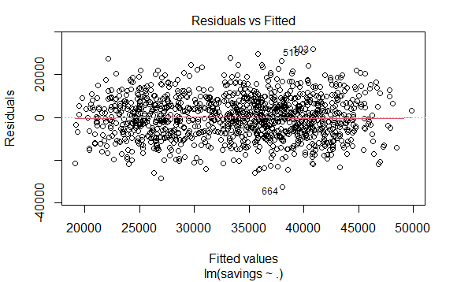

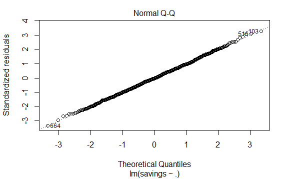

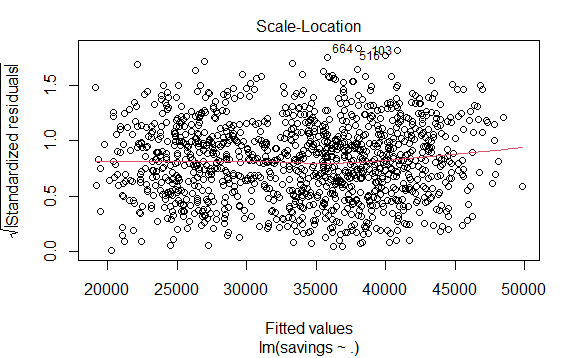

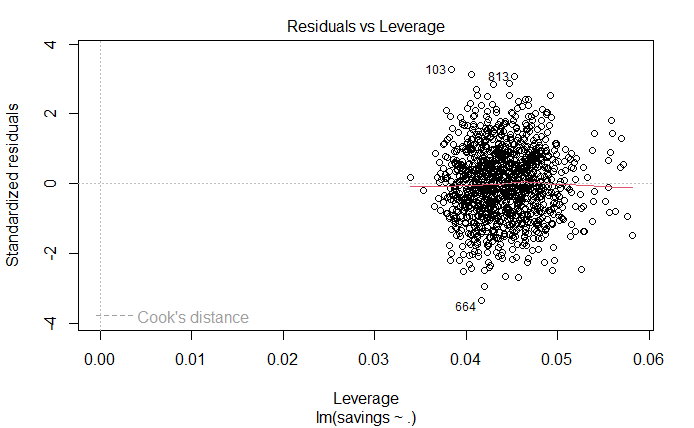

```r
model_overfit <- lm(savings ~ ., savings)

plot(model_overfit)
```

```r
summary(model_overfit)
```

```
Call:
lm(formula = savings ~ ., data = savings)

Residuals:
   Min     1Q Median     3Q    Max
-32617  -6684   -264   6481  31884

Coefficients: (1 not defined because of singularities)
                             Estimate Std. Error t value Pr(>|t|)
(Intercept)                 2.050e+04  2.591e+03   7.915 5.81e-15
genderMale                 -1.049e+03  1.706e+03  -0.615   0.5386
nameAngus                   1.531e+03  1.755e+03   0.873   0.3830
nameBert                   -1.973e+02  1.726e+03  -0.114   0.9090
nameBonnie                  1.261e+03  1.809e+03   0.697   0.4859
nameCara                   -8.515e+02  1.807e+03  -0.471   0.6376
nameCharles                 2.419e+03  1.786e+03   1.354   0.1759
nameDonald                  1.253e+02  1.823e+03   0.069   0.9452
nameDora                   -5.149e+02  1.995e+03  -0.258   0.7964
nameEd                      1.249e+03  1.693e+03   0.738   0.4606
nameEmmy                   -1.062e+03  1.816e+03  -0.585   0.5587
nameFlorence                9.245e+02  1.833e+03   0.504   0.6142
nameFreddy                  6.287e+02  1.792e+03   0.351   0.7257
nameGilly                  -1.518e+03  1.764e+03  -0.861   0.3896
nameGord                   -1.246e+02  1.756e+03  -0.071   0.9435
nameHarry                   3.218e+02  1.742e+03   0.185   0.8535
nameHelena                  4.456e+02  1.748e+03   0.255   0.7988
nameIndia                   9.007e+02  1.785e+03   0.505   0.6139
nameIvan                    9.941e+02  1.780e+03   0.559   0.5766
nameJimmy                          NA         NA      NA       NA
nameJools                   6.287e+02  1.772e+03   0.355   0.7228
surnameFraser              -1.113e+03  1.673e+03  -0.665   0.5060
surnameGaldie               2.034e+03  1.839e+03   1.106   0.2689
surnameHalcrow             -7.546e+02  1.819e+03  -0.415   0.6783
surnameHenderson           -3.788e+02  1.751e+03  -0.216   0.8288
surnameIrvine               3.610e+03  1.713e+03   2.108   0.0353
surnameJamieson             4.129e+02  1.831e+03   0.226   0.8216
surnameJohnson              4.237e+02  1.826e+03   0.232   0.8165
surnameLaurenceso          -3.532e+02  1.839e+03  -0.192   0.8478
surnameLeask                2.301e+03  1.697e+03   1.356   0.1754
surnameManson               1.409e+03  1.670e+03   0.843   0.3992
```

[output cut: 69 more lines]

```
age                        ***
retiredYes                 ***
locationEdinburgh
locationGlasgow
locationInverness
locationOrkney
locationShetland
locationStirling
locationWestern Isles
---
Signif. codes:  0 ‘***’ 0.001 ‘**’ 0.01 ‘*’ 0.05 ‘.’ 0.1 ‘ ’ 1

Residual standard error: 9939 on 1147 degrees of freedom
Multiple R-squared:  0.3345,    Adjusted R-squared:  0.3044
F-statistic: 11.09 on 52 and 1147 DF,  p-value: < 2.2e-16
```

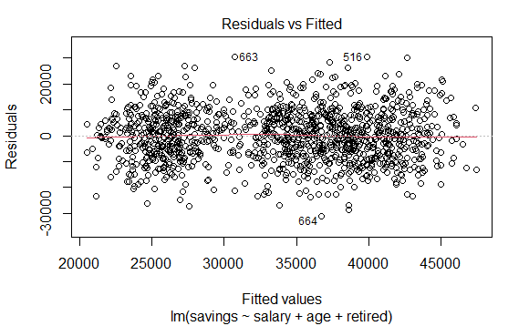

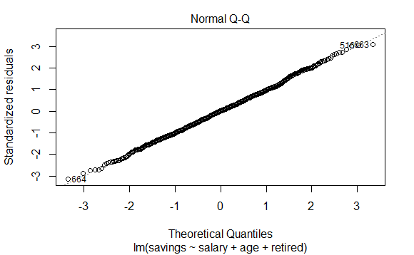

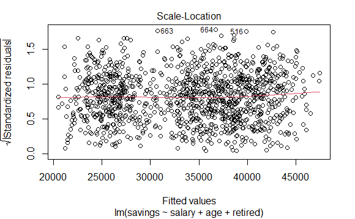

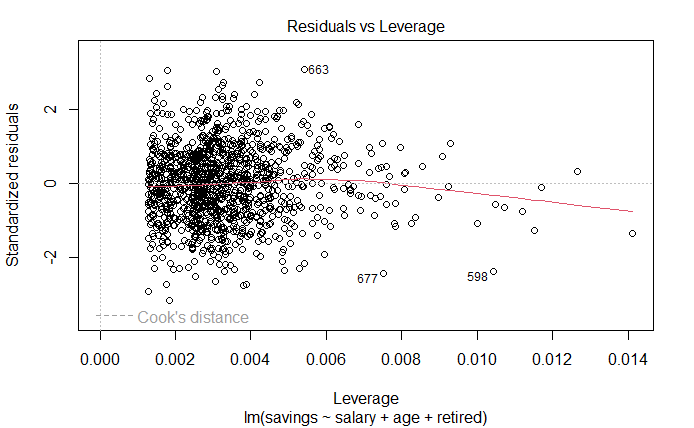

```r
model_wellfit <- lm(savings ~ salary + age + retired,
                    savings)

plot(model_wellfit)
```

```r
summary(model_wellfit)
```

```
Call:
lm(formula = savings ~ salary + age + retired, data = savings)

Residuals:
     Min       1Q   Median       3Q      Max
-31330.5  -6764.2    147.7   6625.2  30518.5

Coefficients:
              Estimate Std. Error t value Pr(>|t|)
(Intercept)  2.125e+04  1.659e+03  12.812  < 2e-16 ***
salary       3.376e-01  6.443e-02   5.239  1.9e-07 ***
age          2.463e+02  2.432e+01  10.127  < 2e-16 ***
retiredYes  -2.102e+04  1.066e+03 -19.710  < 2e-16 ***
---
Signif. codes:  0 ‘***’ 0.001 ‘**’ 0.01 ‘*’ 0.05 ‘.’ 0.1 ‘ ’ 1

Residual standard error: 9918 on 1196 degrees of freedom
Multiple R-squared:  0.309, Adjusted R-squared:  0.3073
F-statistic: 178.3 on 3 and 1196 DF,  p-value: < 2.2e-16
```

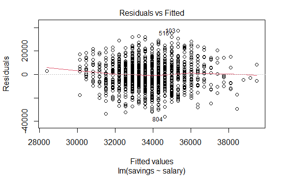

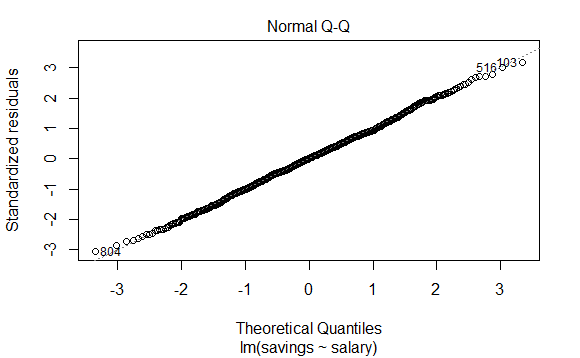

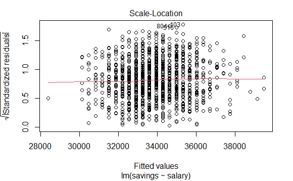

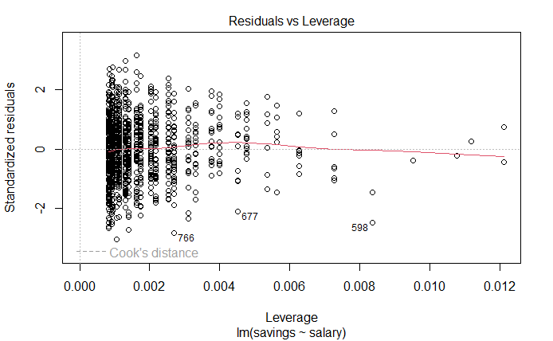

```r
model_underfit <- lm(savings ~ salary, savings)
plot(model_underfit)
```

```r
summary(model_underfit)
```

```
Call:
lm(formula = savings ~ salary, data = savings)

Residuals:
   Min     1Q Median     3Q    Max
-36246  -7847     62   8127  37386

Coefficients:
             Estimate Std. Error t value Pr(>|t|)
(Intercept) 2.701e+04  1.547e+03  17.459  < 2e-16 ***
salary      3.466e-01  7.679e-02   4.514 6.99e-06 ***
---
Signif. codes:  0 ‘***’ 0.001 ‘**’ 0.01 ‘*’ 0.05 ‘.’ 0.1 ‘ ’ 1

Residual standard error: 11820 on 1198 degrees of freedom
Multiple R-squared:  0.01672,   Adjusted R-squared:  0.0159
F-statistic: 20.38 on 1 and 1198 DF,  p-value: 6.992e-06
```

## Parsimony

Goodness of Fit: GoF

R2 adj R2

AIC - Akaike Information Criterion

BIC - Bayesian Information Criterion

Not really GoF measures really they are relative GoF measures Used for comparing models

BIC penalises more strongly - means you tend towards smaller models

R2: larger = better *IC smaller = better

-1000 > -1 > 1

```r
# pull out adjusted r squared values
summary(model_overfit)$adj.r.squared
```

```
[1] 0.304378
```

```r
summary(model_wellfit)$adj.r.squared
```

```
[1] 0.3072727
```

```r
summary(model_underfit)$adj.r.squared
```

```
[1] 0.01590247
```

```r
AIC(model_overfit)
```

```
[1] 25549.42
```

```r
AIC(model_wellfit)
```

```
[1] 25496.62
```

```r
AIC(model_underfit)
```

```
[1] 25915.93
```

```r
BIC(model_overfit)
```

```
[1] 25824.29
```

```r
BIC(model_wellfit)
```

```
[1] 25522.07
```

```r
BIC(model_underfit)
```

```
[1] 25931.2
```

```r
summary(model_overfit)
```

```
Call:
lm(formula = savings ~ ., data = savings)

Residuals:
   Min     1Q Median     3Q    Max
-32617  -6684   -264   6481  31884

Coefficients: (1 not defined because of singularities)
                             Estimate Std. Error t value Pr(>|t|)
(Intercept)                 2.050e+04  2.591e+03   7.915 5.81e-15
genderMale                 -1.049e+03  1.706e+03  -0.615   0.5386
nameAngus                   1.531e+03  1.755e+03   0.873   0.3830
nameBert                   -1.973e+02  1.726e+03  -0.114   0.9090
nameBonnie                  1.261e+03  1.809e+03   0.697   0.4859
nameCara                   -8.515e+02  1.807e+03  -0.471   0.6376
nameCharles                 2.419e+03  1.786e+03   1.354   0.1759
nameDonald                  1.253e+02  1.823e+03   0.069   0.9452
nameDora                   -5.149e+02  1.995e+03  -0.258   0.7964
nameEd                      1.249e+03  1.693e+03   0.738   0.4606
nameEmmy                   -1.062e+03  1.816e+03  -0.585   0.5587
nameFlorence                9.245e+02  1.833e+03   0.504   0.6142
nameFreddy                  6.287e+02  1.792e+03   0.351   0.7257
nameGilly                  -1.518e+03  1.764e+03  -0.861   0.3896
nameGord                   -1.246e+02  1.756e+03  -0.071   0.9435
nameHarry                   3.218e+02  1.742e+03   0.185   0.8535
nameHelena                  4.456e+02  1.748e+03   0.255   0.7988
nameIndia                   9.007e+02  1.785e+03   0.505   0.6139
nameIvan                    9.941e+02  1.780e+03   0.559   0.5766
nameJimmy                          NA         NA      NA       NA
nameJools                   6.287e+02  1.772e+03   0.355   0.7228
surnameFraser              -1.113e+03  1.673e+03  -0.665   0.5060
surnameGaldie               2.034e+03  1.839e+03   1.106   0.2689
surnameHalcrow             -7.546e+02  1.819e+03  -0.415   0.6783
surnameHenderson           -3.788e+02  1.751e+03  -0.216   0.8288
surnameIrvine               3.610e+03  1.713e+03   2.108   0.0353
surnameJamieson             4.129e+02  1.831e+03   0.226   0.8216
surnameJohnson              4.237e+02  1.826e+03   0.232   0.8165
surnameLaurenceso          -3.532e+02  1.839e+03  -0.192   0.8478
surnameLeask                2.301e+03  1.697e+03   1.356   0.1754
surnameManson               1.409e+03  1.670e+03   0.843   0.3992
```

[output cut: 69 more lines]

```
age                        ***
retiredYes                 ***
locationEdinburgh
locationGlasgow
locationInverness
locationOrkney
locationShetland
locationStirling
locationWestern Isles
---
Signif. codes:  0 ‘***’ 0.001 ‘**’ 0.01 ‘*’ 0.05 ‘.’ 0.1 ‘ ’ 1

Residual standard error: 9939 on 1147 degrees of freedom
Multiple R-squared:  0.3345,    Adjusted R-squared:  0.3044
F-statistic: 11.09 on 52 and 1147 DF,  p-value: < 2.2e-16
```

```r
broom::glance(model_overfit)
```

| r.squared | adj.r.squared | sigma | statistic | p.value | df | logLik | AIC | BIC | deviance | df.residual | nobs |
| --- | --- | --- | --- | --- | --- | --- | --- | --- | --- | --- | --- |
| 0.3345468 | 0.304378 | 9939.176 | 11.08918 | 5.293304e-70 | 52 | -12720.71 | 25549.42 | 25824.29 | 113308940089 | 1147 | 1200 |

```r
broom::tidy(model_overfit)
```

| term | estimate | std.error | statistic | p.value |
| --- | --- | --- | --- | --- |
| (Intercept) | 2.050475e+04 | 2.590725e+03 | 7.91467627 | 5.810126e-15 |
| genderMale | -1.049251e+03 | 1.705698e+03 | -0.61514460 | 5.385813e-01 |
| nameAngus | 1.531378e+03 | 1.754631e+03 | 0.87276344 | 3.829747e-01 |
| nameBert | -1.972695e+02 | 1.725841e+03 | -0.11430338 | 9.090173e-01 |
| nameBonnie | 1.261123e+03 | 1.809011e+03 | 0.69713378 | 4.858603e-01 |
| nameCara | -8.515446e+02 | 1.807460e+03 | -0.47112780 | 6.376391e-01 |
| nameCharles | 2.418738e+03 | 1.786041e+03 | 1.35424545 | 1.759248e-01 |
| nameDonald | 1.252874e+02 | 1.822714e+03 | 0.06873673 | 9.452112e-01 |
| nameDora | -5.149016e+02 | 1.995187e+03 | -0.25807183 | 7.963978e-01 |
| nameEd | 1.249415e+03 | 1.692781e+03 | 0.73808421 | 4.606143e-01 |

[output cut: 44 more lines]

```r
NA
```

## Test / train sets

*split data before we look at it*

- ok to go through *basic* cleaning steps
- but don’t explore for patterns or relationships at this point

Create a test set - used to test the model on “unseen” data Separate from training set Don’t refer to it ever again until the model is built

The remaining data is our *training* data

We want to use as much of the data as possible for the training phase

90 / 10 - split 80 / 20 - split 70 / 30 - split

```r
set.seed(9)

n_data <- nrow(savings)

test_index <- sample(1:n_data, size = n_data * 0.2)

test <- slice(savings, test_index)
train <- slice(savings, -test_index)
```

### Fit a model to the training data set

```r
model <- lm(savings ~ salary + age+ retired, train)
ggplot2::autoplot(model)
```

[output not shown]

```r
predictions_test <- test %>%
  add_predictions(model) %>%
  select(savings, pred)

predictions_test
```

| savings | pred |
| --- | --- |
| 54245 | 27957.65 |
| 24199 | 40030.45 |
| 29173 | 22814.27 |
| 18381 | 25751.44 |
| 41128 | 26615.05 |
| 43979 | 42118.50 |
| 22533 | 26101.87 |
| 57821 | 42774.75 |
| 50525 | 39492.36 |
| 29197 | 28683.41 |

[output cut: 230 more lines]

```r
NA
```

```r
mse_test <- mean((predictions_test$pred - test$savings)^2)
mse_test # normally this will be rooted -> RMSE
```

```
[1] 106665166
```

```r
sqrt(mse_test)
```

```
[1] 10327.88
```

[output not shown]

# Task

[output not shown]

## K-fold validation

Bias - variance trade-off

A model with high bias won’t match the data set closely, while a model with low bias will match the data set more closely.

Hyperparameters

```r
cv_10_fold <- trainControl(method = "cv",
                           number = 10,
                           savePredictions = TRUE)

model <- train(savings ~ salary + age + retired,
               savings,
               trControl = cv_10_fold,
               method = "lm")
```

```r
model$pred
```

```r
model$resample
```

```r
mean(model$resample$RMSE)
mean(model$resample$Rsquared)
```

[output not shown]

# Task

```r
cv_10_fold <- trainControl(method = "cv",
                           number = 10,
                           savePredictions = TRUE)

model_all <- train(savings ~ .,
               savings,
               trControl = cv_10_fold,
               method = "lm")

model_all$resample %>%
  summarise(mean_error = mean(RMSE),
            mean_r_squared = mean(Rsquared))
```

[output not shown]

## Test, Training and Validation sets

20 / 80 20 / 60 / 20

Hyperparameters - “model settings”

data some model — lots of different types of model fit several models with varying hyperparameters use the validation set to choose our hyperparameters re-train model on entire training set (60 + 20) test on test set

## Avoiding leaks

- might be ok looking for some correlations
- how do we handle NAs?

if you impute before you split Realise the imputed values in the test set have been influence by the training set

impute values independently between test and training data set.